# 06_B_MovingAverages_TrendEstimation

# References

1. Hyndman, R.J., & Athanasopoulos, G., 2021. *Forecasting: principles and practice*. 3rd edition.

This material is not original. It extends parts of reference 1 with further explanation.

# Packages

```r
library(fpp3)
```

# Moving averages

## Introduction

Most decomposition algorithms start by estimating the trend, because the trend is easier to pull out of a raw series than the seasonal component is.

In this notebook we are going to study how to produce estimates of the trend using the **moving average**, which is what the **classical decomposition algorithm does**.

Moving averages are used well beyond decomposition, so this notebook covers a few points that go past what the algorithm strictly needs.

## The concept of a moving average

**Given a time series $y_t$**, a **moving average of $y_t$ is another series, built by averaging $y_t$ inside a window that slides along it**. At each point in time you average the neighboring values that the window happens to cover.

## First example

Consider the example below. We have:

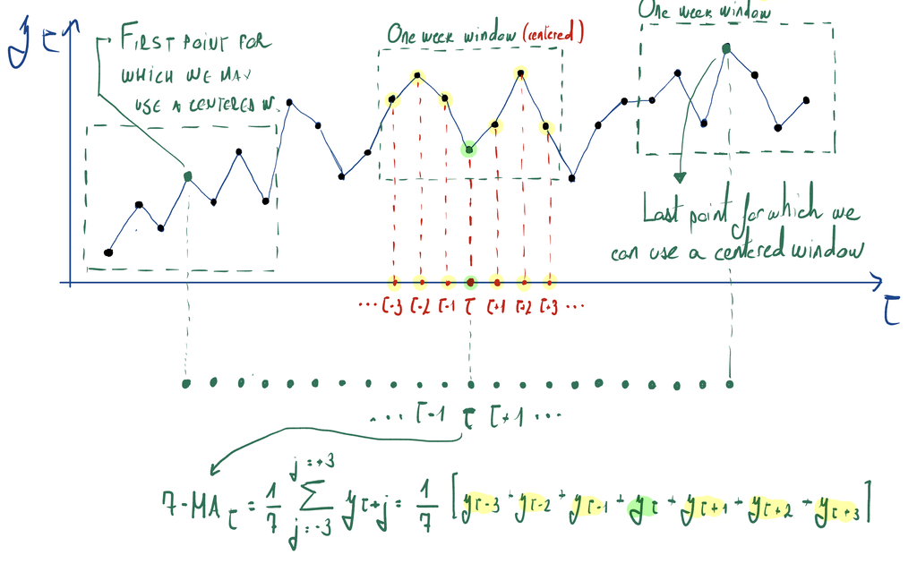

Because the window chosen has 7 points, we will call the resulting time series the $7-MA_t$ of $y_t$.

By shifting this window we could compute the value of the moving average time series at every instant in time. For example, **to compute the value of the moving average at point $t+1$ instead of $t$, we need to shift the window used for point $t$ one timestep to the right**. This results in the **purple window in the figure below**. The corresponding formula for the 7-MA at $t+1$ has also been included.

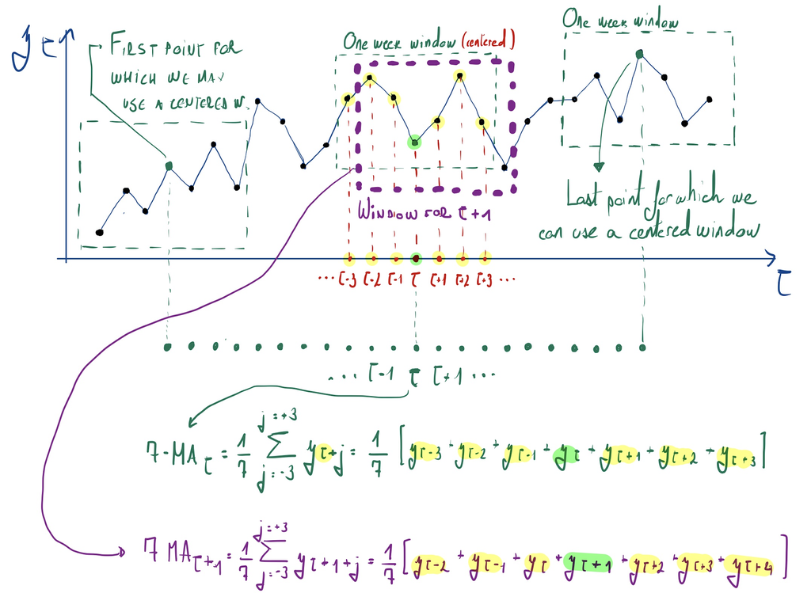

### Important difference between windows at $t$ and at $t+1$ (neighboring windows)

- These windows **differ in two points**.
  - The window for $t$ includes $y_{t-3}$ but not $y_{t+4}$.
  - The window for $t+1$ includes $y_{t+4}$ but not $y_{t-3}$.

In general, **two neighboring windows will differ in only two points**. This will be important for understanding the effect of window sizes later in this notebook.

### Limitation of centered windows

The **points at the extremes do not have complete windows and therefore we will not compute the moving average at these points.**

## Centered moving averages

### Windows with an odd number of points

We care about centered moving averages for two reasons. A centered window usually carries the smallest approximation error, and classical decomposition uses one to estimate the trend.

**The centered moving average** of order m can be written as:

$$m-MA \text{ }_t =\frac{1}{m}\sum_{j=-k}^{j=+k}{y_{t+j}}$$

where: **$m = 2k+1$**.

- $m=2k+1$ is the number of points in the window. Because we are using centered windows, we need the number of points $m$ to be odd (hence $2k+1$). That way we can leave as many points to the left as to the right.
- the sum runs from $j=-k$ to $j=+k$ and passes through $j=0$ (hence $2k+1$ points).

For example, a 7 order moving average like the one in the example before would have the following formula:

$$7-MA_t =\frac{1}{7}\sum_{j=-3}^{j=+3}{y_{t+j}} = \frac{1}{7}(y_{t-3}+y_{t-2}+y_{t-1}+y_t+y_{t+1}+y_{t+2}+y_{t+3})$$

#### Example in R

In R, we are going to compute moving averages using the function `slider::slide_dbl()`. This function takes the following arguments:

- The **first argument** is the name of the column (or vector) containing the time series for which we wish to compute the moving average.
- The **second argument** is the aggregate function we wish to apply to the points covered by the window. Since we are computing moving averages, we will pass the function `mean`.
- The argument `.before` specifies the number of points in the window to the left of the point at which we are computing the moving average. In the example above (a $7-MA_t$), this number is 3 (the yellow points to the left in the previous figures of the 7-MA).
- The argument `.after` specifies the number of points in the window to the right of the point at which we are computing the moving average. In the example above (a $7-MA_t$), this number is 3 (the yellow points to the right in the previous figures of the 7-MA).

Read the code below and make sure you can see how the $7-MA_t$ is computed:

```r
aus_exports <-

  global_economy |>

  filter(Country == "Australia") |>

  # Generate the moving average
  mutate(

    # The slider function applies a function to "sliding" time windows.
    # In this case it is a 7-MA because we are moving from j=-3 (before = 3)
    # to j=+3 (after = 3).
    `7-MA` = slider::slide_dbl(Exports, mean,

                # .complete = TRUE -> function evaluated only on full windows
                # This means that the MA will not be computed for the first
                # and last three points of the time series
                .before = 3, .after = 3, .complete = TRUE)
  ) |>

  select(Country, Code, Year, Exports, `7-MA`)

aus_exports
```

```
# A tsibble: 58 x 5 [1Y]
# Key:       Country [1]
   Country   Code   Year Exports `7-MA`
   <fct>     <fct> <dbl>   <dbl>  <dbl>
 1 Australia AUS    1960    13.0   NA
 2 Australia AUS    1961    12.4   NA
 3 Australia AUS    1962    13.9   NA
 4 Australia AUS    1963    13.0   13.3
 5 Australia AUS    1964    14.9   13.3
 6 Australia AUS    1965    13.2   13.3
 7 Australia AUS    1966    12.9   13.0
 8 Australia AUS    1967    12.9   13.0
 9 Australia AUS    1968    12.3   12.7
10 Australia AUS    1969    12.0   12.6
# ℹ 48 more rows
```

Now a sanity check, using the habit from Session 5. Take the first seven values of `Exports`, average them by hand, and check the result against the first value the 7-MA produced:

```r
all.equal(mean(aus_exports$Exports[1:7]), aus_exports$`7-MA`[[4]])
```

```
[1] TRUE
```

Remember what Session 5 established: on its own, `all.equal()` returns `TRUE` or a character string describing the gap, never `FALSE`. Wrap it in `isTRUE()` whenever you need a plain logical you can act on:

```r
isTRUE(all.equal(mean(aus_exports$Exports[1:7]), aus_exports$`7-MA`[[4]]))
```

```
[1] TRUE
```

The fourth element is the first one the 7-MA can produce: with three points needed on each side, the first three windows are incomplete and `.complete = TRUE` leaves them as `NA`.

Now plot the moving average over the original series:

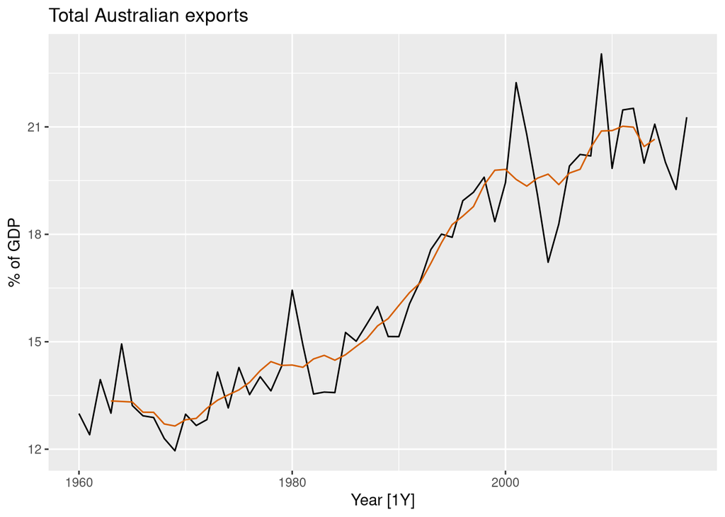

```r
aus_exports |>
  autoplot(Exports) +

  geom_line(aes(y = `7-MA`), colour = "#D55E00") +

  labs(y = "% of GDP",
       title = "Total Australian exports")
```

### Effect of window size on the moving average

Now build several centered moving averages of the same series, each over a different number of points. **The number is always odd**, so that each window stays centered:

```r
aus_exports <- global_economy |> filter(Country=='Australia')

# Create the different Moving Averages of order i.
# Note that i is always odd
for (i in seq(3, 13, by = 2)){

    col_name <- paste0(as.character(i), "-MA")

    width = (i-1)/2 # Number of points to leave to the left and to the right

    aus_exports[[col_name]] = slider::slide_dbl(aus_exports$Exports, mean,

                              # .complete = TRUE -> function evaluated only on full windows
                              .before = width, .after = width, .complete = TRUE)

}

aus_exports <- aus_exports |>
                  select(Exports, `3-MA`, `5-MA`, `7-MA`, `9-MA`, `11-MA`, `13-MA`)

aus_exports
```

```
# A tsibble: 58 x 8 [1Y]
   Exports `3-MA` `5-MA` `7-MA` `9-MA` `11-MA` `13-MA`  Year
     <dbl>  <dbl>  <dbl>  <dbl>  <dbl>   <dbl>   <dbl> <dbl>
 1    13.0   NA     NA     NA     NA      NA      NA    1960
 2    12.4   13.1   NA     NA     NA      NA      NA    1961
 3    13.9   13.1   13.5   NA     NA      NA      NA    1962
 4    13.0   14.0   13.5   13.3   NA      NA      NA    1963
 5    14.9   13.7   13.6   13.3   13.2    NA      NA    1964
 6    13.2   13.7   13.4   13.3   13.1    13.1    NA    1965
 7    12.9   13.0   13.3   13.0   13.1    13.0    13.0  1966
 8    12.9   12.7   12.7   13.0   13.0    13.1    13.1  1967
 9    12.3   12.4   12.6   12.7   13.0    13.1    13.1  1968
10    12.0   12.4   12.6   12.6   12.9    13.1    13.2  1969
# ℹ 48 more rows
```

Plotting them gives the graphs below.

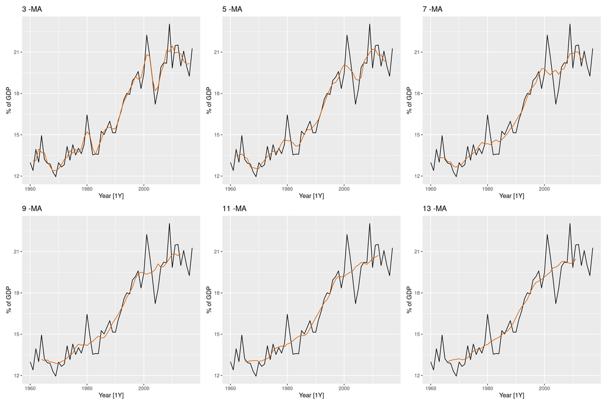

Note that:

1. More points in the window give a smoother curve.
   - Each shift of the window swaps only two points, however wide the window is. **So the more points the window holds, the less the average can move on any one shift**, and the smoother the resulting curve.
2. Because we are using centered moving averages and we have required our windows to be complete (we used `.complete = TRUE`), no values are computed for the first $(m-1)/2$ points or the last $(m-1)/2$ points.

### Windows with an even number of points

So far **we have required that $m = 2k+1$**, which is to say that **$m$ be odd**. That condition is what gave us the same number of points to the left and to the right of the point we are averaging at, which is exactly what a centered window needs.

**How do we center a moving average over an even number of points?**

This problem is **important** because, for series with seasonality, we want to average over the whole seasonal period.

- for weekly data (period length of 7) we can compute a centered moving average with the same amount of points to both sides.
- for monthly data (period length of 12) or quarterly data (period length of 4) a centered moving average cannot be directly computed. We cannot leave the same amount of points to the left and to the right.

If the number of points is even, we cannot use a centered window. That is, if $m$ (the number of points contained in the moving average window) is even, then we will have either one more point to the left or one more point to the right of the point at which we are computing the moving average.

There is a way around it:

1. Compute a moving average using an *imbalanced* window with more points to the right than to the left.
2. Compute a moving average using an *imbalanced* window with more points to the left than to the right.
3. Compute the mean of both moving averages.

The figure below works an example through. We want a 4-MA, a window of four points, centered by the process just described:

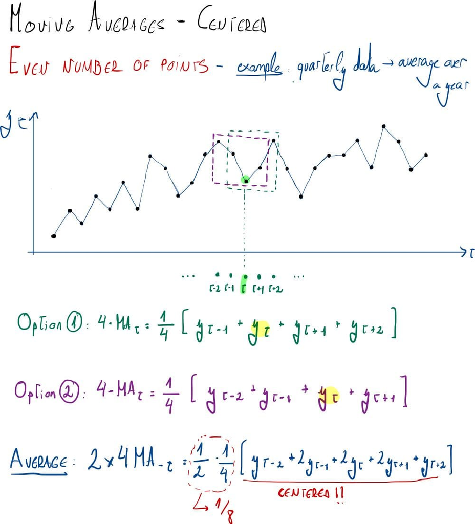

1. We start by computing the $4-MA_t$ with a window that picks **1 point to the left of the point at which we are computing the MA and 2 points to the right**. This would be the green window in the figure above. Using this window we compute the $4-MA$ at every point, wherever we can build a complete window. Since this window has more points to the right than to the left, we will call it $4-MA_t \ R$

$$4-MA_t \ R = \frac{1}{4}[y_{t-1}+y_t+y_{t+1}+y_{t+2}]$$

2. We then compute the $4-MA_t$ with a window that picks **2 points to the left of the point at which we are computing the MA and 1 point to the right**. Since this window has more points to the left than to the right, we will call it $4-MA_t \ L$

$$4-MA_t \ L = \frac{1}{4}[y_{t-2}+y_{t-1}+y_{t}+y_{t+1}]$$

3. We now take the average of $4-MA_t \ R$ and $4-MA_t \ L$. Because we are averaging 2 $4-MA$ series (L and R), we will call the ouput $2x4-MA_t$

$$\frac{1}{2} [ \ 4-MA_t \ R + 4-MA_t \ L \ ] = \frac{1}{2} \cdot \frac{1}{4} [ \ y_{t-2}+2y_{t-1}+2y_{t}+2y_{t+1}+y_{t+2} \ ]$$

Expanding gives:

$$\frac{1}{8} y_{t-2} + \frac{1}{4} [y_{t-1}+y_{t}+y_{t+1}] + \frac{1}{8} y_{t+2}$$

We can write this as a **weighted moving average**:

$$\sum_{j=-k}^{j=k}{a_j \cdot y_{t+j}}$$

where:

1. $a_j$ are the coefficients associated to each $y_j$. In this case, the list of $a_j$ would be $[\frac{1}{8},\frac{1}{4},\frac{1}{4},\frac{1}{4},\frac{1}{8}]$.
2. $k = m/2$ (in this case $m$ is even, so it can be divided by 2)

These coefficients $a_j$ have **two important properties**:

1. $\sum_{j=-k}^{j=k}{a_j} = 1$. The weights add up to 1
2. $a_j= a_{-j}$. The weights are symmetric.

Those two properties make the sum a **weighted average**, and a **symmetric** one.

The procedure generalizes from four points to **any even window**:

- A *2 x m-MA* (*$m$ even*) is equivalent a centered weighted moving average of $m+1$ points, where all observations take weights $1/m$, except for the first and last term, which take weights $1/(2m)$.

#### Example in R

Apply this to quarterly beer production in Australia from 1992 onward:

```r
# Filter dataset
beer <- aus_production |>
  filter(year(Quarter) >= 1992) |>
  select(Quarter, Beer)

beer <-
  beer |>
  mutate(
    # Imbalanced window for the first 4-MA: 1 point to the left, two
    # points to the right
    `4-MA_R` = slider::slide_dbl(Beer, mean,
                .before = 1, .after = 2, .complete = TRUE),

    # Imbalanced window for the second 4-MA: 2 points to the left, 1
    # point to the right
    `4-MA_L` = slider::slide_dbl(Beer, mean,
                .before = 2, .after = 1, .complete = TRUE),

    # Average of both moving averages
    `2x4-MA` = 0.5 * (`4-MA_R` + `4-MA_L`)
  )

beer |> select(Quarter, Beer, `4-MA_R`, `4-MA_L`, `2x4-MA`) |> head(5)
```

```
# A tsibble: 5 x 5 [1Q]
  Quarter  Beer `4-MA_R` `4-MA_L` `2x4-MA`
    <qtr> <dbl>    <dbl>    <dbl>    <dbl>
1 1992 Q1   443      NA       NA       NA
2 1992 Q2   410     451.      NA       NA
3 1992 Q3   420     449.     451.     450
4 1992 Q4   532     452.     449.     450.
5 1993 Q1   433     449      452.     450.
```

```r
beer |> select(Quarter, Beer, `4-MA_R`, `4-MA_L`, `2x4-MA`) |> tail(5)
```

```
# A tsibble: 5 x 5 [1Q]
  Quarter  Beer `4-MA_R` `4-MA_L` `2x4-MA`
    <qtr> <dbl>    <dbl>    <dbl>    <dbl>
1 2009 Q2   398     430      430      430
2 2009 Q3   419     430.     430      430.
3 2009 Q4   488     424.     430.     427.
4 2010 Q1   414      NA      424.      NA
5 2010 Q2   374      NA       NA       NA
```

Now plot the moving average over the original series:

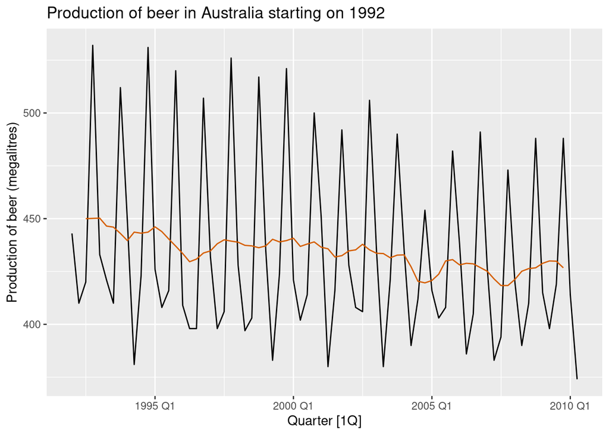

```r
beer |>

  autoplot(Beer) +

  geom_line(aes(y = `2x4-MA`), colour = "#D55E00") +

  labs(y = "Production of beer (megalitres)",
       title = "Production of beer in Australia starting on 1992")
```

# Left and right moving averages

We use centered moving averages because centered approximations usually carry the smaller error. Near the ends of the series a centered window no longer fits, so you have to shift to a one-sided average.

Because of this, algorithms using window functions usually offer the option to transition to a one-sided (left or right) moving average as they approach the extremes (beginning and end) of the time series:

- **Left moving average:** window considers the point in time at which we are computing and points to its left

$$\frac{1}{m}\sum_{j=-(m-1)}^{j=0}{y_{t+j}}$$

- **Right moving average:** window considers the point in time at which we are computing and points to its right:

$$\frac{1}{m}\sum_{j=0}^{j=m-1}{y_{t+j}}$$

This course uses centered moving averages only. It is worth knowing the alternatives exist.

# Exercise 1

The series below counts the people employed in US retail from 1990 onward:

```r
# Filter the series and select relevant columns
us_retail_employment <-
  us_employment |>
  filter(year(Month) >= 1990, Title == "Retail Trade") |>
  select(-Series_ID)
```

Compute the 2x12 Moving Average of the time series `Employed` contained in `us_retail_employment`.

## We’ll discuss potential solutions during the live session.

# Exercise 2

Take the dataset `vic_elec` and aggregate the data to obtain the mean quarterly half hourly demand using `index_by()`. That is, for each quarter, compute the mean half-hourly demand.

Then compute a 2x4-MA of the resulting series that is centered.

## We’ll discuss potential solutions during the live session.

# Exercise 3

Deduce the formula for a $3x7-MA$ of a time series $y_t$. That is, compute a 7-MA and then average 3 neighboring windows (centered at $t-1$, $t$ and $t+1$) to produce the $3x7-MA$.

# Exercise 4

Deduce the formula for a $2x8-MA$ of a time series $y_t$. For this, follow an analogous procedure to the one outlined for the $2x4-MA$.

# Blank picture to practice

Here is a blank time series, so that you can **draw the windows for exercises 3 and 4 by hand and work the formulas out on paper**.

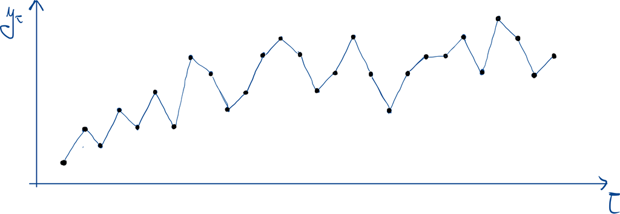